# Algorithm

Algorithm

7. Network Flow III

WU Xiaokun 吴晓堃

xkun.wu [at] gmail

2021/11/12

# Assignment problem

## Assignment problem

**Input**. Weighted, complete bipartite graph $G = (X \cup Y, E)$ with $|X| = |Y|$.

**Goal**. Find a perfect matching of min weight.

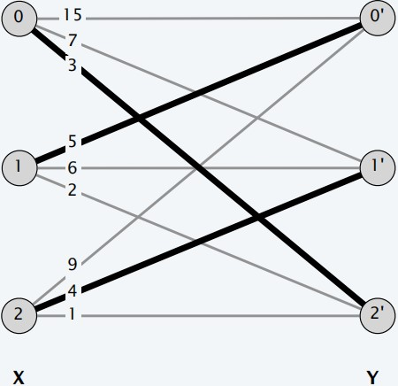

min-cost perfect matching M = { 0-2’, 1-0’, 2-1’ }

$cost(M) = 3 + 5 + 4 = 12$

## Seminar assignment

**Goal**. Given $m$ seminars and $n = 12m$ students who rank their top $8$ choices, assign each student to one seminar so that:

- Each seminar is assigned exactly $12$ students.
- Students tend to be “happy” with their assigned seminar.

**Solution**.

- Create one node for each student $i$ and $12$ nodes for each seminar $j$.
- Solve assignment problem where $c_{ij}$ is some function $f$ of the ranks:

$$c_{ij} = \left\{ \begin{array}{ll}
f(rank(i,j)) & \text{if}\ i\ \text{ranks}\ j \\
\infty & \text{otherwise} \\
\end{array}\right.$$

## Applications

Natural applications.

- Match jobs to machines.
- Match personnel to tasks.
- Match students to seminars.

Non-obvious applications.

- Vehicle routing.
- Signal processing.
- Earth-mover’s distance.
- Multiple object tracking.
- Virtual output queueing.
- Handwriting recognition.
- Locating objects in space.
- Approximate string matching.
- Enhance accuracy of solving linear systems of equations.

## Bipartite matching

**Bipartite matching**. Can solve via reduction to maximum flow.

**Flow**. During Ford-Fulkerson, all residual capacities and flows are 0-1; flow corresponds to edges in a matching $M$.

**Residual graph $G_M$** simplifies to:

- If $(x, y) \notin M$, then $(x, y)$ is in $G_M$.
- If $(x, y) \in M$, then $(y, x)$ is in $G_M$.

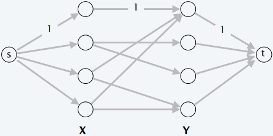

**Augmenting path** simplifies to:

- Edge from $s$ to an unmatched node $x \in X$,
- Alternating sequence of unmatched and matched edges,
- Edge from unmatched node $y \in Y$ to $t$.

## Alternating path

**Def**. An **alternating path** $P$ with respect to a matching $M$ is an alternating sequence of unmatched and matched edges, starting from an unmatched node $x \in X$ and going to an unmatched node $y \in Y$.

**Key property**. Can use $P$ to increase by one the cardinality of the matching.  
**Pf**. Set $Mʹ = M \ominus P$.

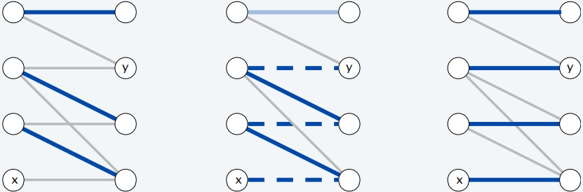

## Successive shortest path

**Cost of alternating path**. Pay $c(x, y)$ to match $x$-$y$; receive $c(x, y)$ to unmatch.

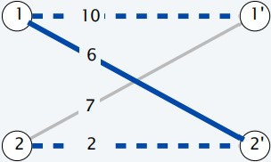

$P = 2 \rightarrow 2' \rightarrow 1 \rightarrow 1'$

$cost(P) = 2 - 6 + 10 = 6$

**Shortest alternating path**. Alternating path from any unmatched node $x \in X$ to any unmatched node $y \in Y$ with minimum cost.

**Successive shortest path algorithm**.

- Start with empty matching.
- Repeatedly augment along a *shortest* alternating path.

## Finding the shortest alternating path

**Shortest alternating path**. Corresponds to minimum cost $s↝t$ path in $G_M$.

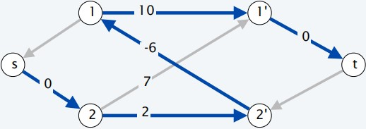

**Concern**. Edge costs can be negative.

**Fact**. If always choose shortest alternating path, then $G_M$ contains no negative cycles $\Rightarrow$ can compute using Bellman-Ford.

**Our plan**. Use *duality* to avoid negative edge costs (and negative cycles) $\Rightarrow$ can compute using Dijkstra.

## Equivalent assignment problem

**Duality intuition**. Adding a constant $p(x)$ to the cost of every edge incident to node $x \in X$ does not change the min-cost perfect matching(s).  
**Pf**. Every perfect matching uses exactly one edge incident to node $x$.

**Duality intuition**. Adding a constant $p(y)$ to the cost of every edge incident to node $y \in Y$ does not change the min-cost perfect matching(s).  
**Pf**. Every perfect matching uses exactly one edge incident to node $y$.

## Reduced costs

**Reduced costs**. For $x \in X, y \in Y$, define $c^p(x, y) = p(x) + c(x, y) - p(y)$.

**Observation 1**. Finding a min-cost perfect matching with reduced costs is equivalent to finding a min-cost perfect matching with original costs.

## Compatible prices

**Compatible prices**. For each node $v \in X \cup Y$, maintain prices $p(v)$ such that:

- $c^p(x, y) \ge 0$ for all $(x, y) \notin M$.
- $c^p(x, y) = 0$ for all $(x, y) \in M$.

**Observation 2**. If prices $p$ are compatible with a perfect matching $M$, then $M$ is a min-cost perfect matching.  
**Pf**. Matching $M$ has $0$ cost.

## Successive shortest path: algorithm

`SUCCESSIVE-SHORTEST-PATH` ($X, Y, c$)

1. $M = \emptyset$;
2. FOREACH $v \in X \cup Y$: $p(v) = 0$;
3. WHILE ($M$ is not a perfect matching)
   1. $d$ = shortest path distances using costs $c^p$;
   2. $P$ = shortest alternating path using costs c^p;
   3. $M$ = updated matching after augmenting along $P$;
   4. FOREACH $v \in X \cup Y$: $p(v) = p(v) + d(v)$; RETURN M;

## Successive shortest path: demo

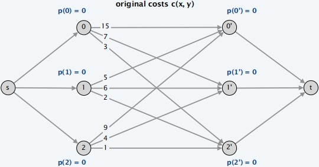

## Maintaining compatible prices 1

**Lemma 1**. Let $p$ be compatible prices for $M$. Let $d$ be shortest path distances in $G_M$ with costs $c^p$. All edges $(x, y)$ on shortest path have $c^{p+d}(x, y)$ = 0.  
**Pf**. Let $(x, y)$ be some edge on shortest path.

- If $(x, y) \in M$, then $(y, x)$ on shortest path and $d(x) = d(y) - c^p(x, y)$;
- $If (x, y) \notin M$, then $(x, y)$ on shortest path and $d(y) = d(x) + c^p(x, y)$.
- In either case, $d(x) + c^p(x, y) - d(y) = 0$.
- By definition, $c^p(x, y) = p(x) + c(x, y) - p(y)$.
- Substituting for $c^p(x, y)$ yields $(p(x) + d(x)) + c(x, y) - (p(y) + d(y)) = 0$.
  - In other words, $c^{p+d}(x, y) = 0$.

## Maintaining compatible prices 2

**Lemma 2**. Let $p$ be compatible prices for $M$. Let $d$ be shortest path distances in $G_M$ with costs $c^p$. Then $pʹ = p + d$ are also compatible prices for $M$.  
**Pf**. $(x, y) ∈ M$

- $(y, x)$ is the only edge entering $x$ in $G_M$. Thus, $(y, x)$ on shortest path.
- By LEMMA 1, $c^{p+d}(x, y) = 0$.

**Pf**. $(x, y) ∉ M$

- $(x, y)$ is an edge in $G_M \Rightarrow d(y) \le d(x) + c^p(x, y)$.
- Substituting $c^p(x, y) = p(x) + c(x, y) - p(y) \ge 0$ yields $(p(x) + d(x)) + c(x, y) - (p(y) + d(y)) \ge 0$.
  - In other words, $c^{p+d}(x, y) \ge 0$.

## Maintaining compatible prices 3

**Lemma 3**. Let $p$ be compatible prices for $M$ and let $Mʹ$ be matching obtained by augmenting along a min cost path with respect to $c^{p+d}$. Then $pʹ = p + d$ are compatible prices for $Mʹ$.  
**Pf**.

- By LEMMA 2, the prices $p + d$ are compatible for $M$.
- Since we augment along a min-cost path, the only edges $(x, y)$ that swap into or out of the matching are on the min-cost path.
- By LEMMA 1, these edges satisfy $c^{p+d}(x, y) = 0$.
- Thus, compatibility is maintained.

## Successive shortest path: analysis

**Invariant**. The algorithm maintains a matching $M$ and compatible prices $p$.  
**Pf**. Follows from LEMMA 2 and LEMMA 3 and initial choice of prices.

**Theorem**. The algorithm returns a min-cost perfect matching.  
**Pf**. Upon termination $M$ is a perfect matching, and $p$ are compatible prices. Optimality follows from OBSERVATION 2.

**Theorem**. The algorithm can be implemented in $O(n^3)$ time.  
**Pf**.

- Each iteration increases the cardinality of $M$ by $1 \Rightarrow n$ iterations.
- Bottleneck operation is computing shortest path distances $d$. Since all costs are nonnegative, each iteration takes $O(n^2)$ time using (dense) Dijkstra.

## Weighted bipartite matching

**Weighted bipartite matching**. Given a weighted bipartite graph with $n$ nodes and $m$ edges, find a maximum cardinality matching of minimum weight.

**Theorem**. [Gabow-Tarjan 1989] There exists an $O(m n^{1/2} \log(nC))$ time algorithm for the problem when the costs are integers between $0$ and $C$.

# Input-queued switching

## Input-queued switching Problem

**Input-queued switch**.

- $n$ input ports and $n$ output ports in an $n$-by-$n$ crossbar layout.
- At most one cell can depart an input at a time.
- At most one cell can arrive at an output at a time.
- Cell arrives at input $x$ and must be routed to output $y$.

**Application**. High-bandwidth switches.

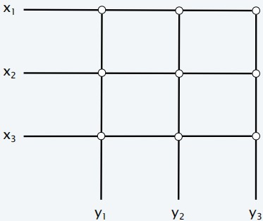